# Errabun_2

# Prolegómeno

Recordemos que Abundio estaba cogiendo espárragos en [*las afueras*](https://jmb-uma.github.io/rbund), una región del espacio-tiempo peculiar. Gracias a un sueño en el que aparecieron sus amigos de cuando chicho, pudo descartar las estrategias basadas en puro azar.

# Memoria

Para evitar pasar varias veces por el mismo sitio pensó en dejar alguna marca (como la huella del pie). Caminaría en una dirección hasta toparse con algún espárrago o su propia huella y, entonces, cambiaría de dirección. El propio prado contendría la información de su paseo, como una especie de memoria física. Para representar el asunto, pensó en un prado con `0` en las casillas que no había pisado y `1` en las que sí.

# Autómata

Como ya conocía las propiedades topológicas del prado, aunque cambiasen misteriosamente las plantas de vez en cuando, recordó su primer paseo antes de ponerse a andar de nuevo.

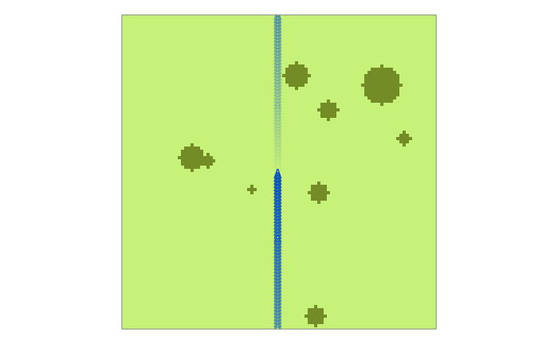

```r
{
#---- Colores
c_campo <- rgb(0.78, 0.95, 0.48)
c_amg <- rgb(0, 0.31, 0.74)
c_espar <- rgb(0.45, 0.55, 0.15)

#---- Espacio
xmax <- 100  # ancho de la pradera (desde x = 1 hasta x = 100)
ymax <- 100  # largo "        "    (desde y = 1 hasta y = 100)

#---- Tiempo
pasos <- 101

#---- Movimiento
Dx <- c(0, 1, 0, -1)
Dy <- c(1, 0, -1, 0)

#---- Pradera con esparragueras
par(pty = "s", mar = c(1, 1, 1, 1), xaxt = "n", yaxt = "n",
    xaxs = "i", yaxs="i", ann = FALSE)
XYespar <- t(as.matrix(read.table("XYesp.txt")))
image(x = 1:xmax, y = 1:ymax, XYespar, xlim = c(1,xmax), ylim = c(1,ymax),
      col = c(c_campo, c_espar))

#---- Posición y orientación de Abundio
Ax <- ceiling(0.5*xmax)
Ay <- ceiling(0.5*xmax)
Ad <- 1  # mira al norte
text(Ax, Ay, "A", col = "white")

#---- Paseo
for (t in 2:pasos){

  # Abundio se mueve
  Ax <- Ax + Dx[Ad]
  Ay <- Ay + Dy[Ad]
  if(Ax > xmax) {Ax <- 1} # por si se sale
  if(Ax < 1) {Ax <- xmax}
  if(Ay > ymax) {Ay <- 1}
  if(Ay < 1) {Ay <- ymax}

  # Dibujamos la nueva posición
  text(Ax, Ay, "A", col = rgb(0, 0.31, 0.74, alpha = t/pasos))
}
}
```

**Figura 1. Primer paseo de Abundio.** Después de 100 pasos hacia el norte volvía al mismo lugar donde empezó.

Sabía que se encontraría en el mismo lugar después de 100 pasos. Entonces, para salirse de su propio camino, daría un paso al este y seguiría de nuevo hacia el norte, así hasta volver a encontrar sus huellas. Pensaba que así podría recorrer todas las casillas de la pradera de forma sistemática.

Se le ocurrió hacer un diagrama para representar la estrategia del movimiento. Así que se sentó en el marmolillo y empezó a dibujar (Figura 2).

[figure not shown]

**Figura 2. El primer autómata.** Las reglas del movimiento se representaban con flechas y un código de tres caracteres. Así `01N` significaba: si encuentro un 0, escribo un 1 y me muevo al norte. Si encontrase un 1, es que ya habría pasado por allí, así que dejaría el 1 y se movería un paso al este, para seguir como antes, estrategia que se representaba con otra flecha distinta y el código `11E`.

A ver…

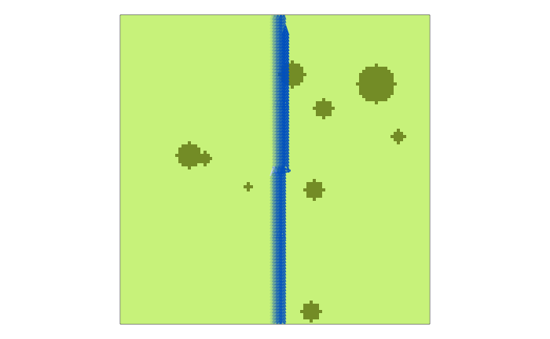

**Figura 3. Paseo del primer autómata.** Cuando encontraba una casilla que había pisado, se movía un paso al este y seguía explorando hacia el norte.

—¡No está mal! —exclamó Abundio, más entusiasmado con el resultado del paseo que con los espárragos que podía haber cogido.

Como en su primer trayecto septentrional no pilló ningún espárrago, se dio cuenta de que con esa estrategia siempre entraría en contacto con las esparragueras por la derecha, por el este, mejor dicho. Entonces pensó que debía añadir una nueva habilidad a su autómata.

# Abecedario y estados

Para distinguir las casillas vacías de las que tenían espárragos señaló estas con un `2`. Ya se iba formando una especie de *abecedario*:

- `0` : casillas vacías que no había pisado
- `1` : casillas que había pisado
- `2` : casillas con espárrago que aún no había pisado

Comprendió que el autómata debería reaccionar cuando se encontrara un espárrago, ¡probablemente hubiera otros por allí cerca! Para codificar este cambio de *estado* utilizó una nueva letra y más flechas en el diagrama (Figura 4).

[figure not shown]

**Figura 4. Un nuevo estado.** Cuando encontrase un espárrago, el autómata cambiaría al estado `B` e intentaría *seguir buscando por allí cerca*.

*Buscando por allí cerca* era una expresión demasiado indefinida para codificarla. Estaba seguro de que el nuevo diagrama no iba a funcionar a la perfección, en particular lo de moverse al sur y pasar al estado `A` cuando estuviera en `B` y pisara una casilla ya visitada, pero era lo mejor que se le ocurrió en ese momento. Ahora su principal problema era tratar con tantas condicionales. Si tuviera que hacerlo con `IF-ELSE` no acabaría nunca, por más lento que fuese el tiempo en la pradera.

# Cromosoma

Para ordenar las contingencias posibles, las organizó en una tabla.

[figure not shown]

**Tabla 1.** Tabla de contingencias correspondiente al autómata de la Figura 4. Las filas representan el estado en el que se puede encontrar y las columnas el valor que hay en la casilla. En cada intersección de ambas hay tres caracteres: lo que escribirá en la casilla, la dirección en la que moverá y el estado al que cambiará.

Si tenía cuidado y no se confundía con el orden, la tabla se podía escribir como la secuencia de caracteres `1NA1EA1EB1EB1SA1NA` vamos, ¡un auténtico cromosoma! Ahora el autómata solo tenía que mirar en la posición adecuada del cromosoma para saber qué hacer.

```r
#---- Colores
c_campo <- rgb(0.78, 0.95, 0.48)
c_amg <- rgb(0, 0.31, 0.74)
c_espar <- rgb(0.45, 0.55, 0.15)

#---- Espacio
xmax <- 100  # ancho de la pradera (desde x = 1 hasta x = 100)
ymax <- 100  # largo "        "    (desde y = 1 hasta y = 100)

#---- Tiempo
pasos <- 1000

#---- Movimiento
Dx <- c(0, 1, 0, -1)
Dy <- c(1, 0, -1, 0)
rota <- c(0, 270, 180, 90)

#---- Estados
estados <- "AB"

#---- Cromosoma
cromA <- "1NA1EA1EB1EB1SA1NA"
cromN <- "110120121121130110" # versión numérica, más fácil de leer

#---- Pradera con esparragueras
par(pty = "s", mar = c(1, 1, 1, 1), xaxt = "n", yaxt = "n",
    xaxs = "i", yaxs="i", ann = FALSE)
XYespar <- t(as.matrix(read.table("XYesp.txt")))
image(x = 1:xmax, y = 1:ymax, XYespar, xlim = c(1,xmax), ylim = c(1,ymax),
      col = c(c_campo, c_espar))

#---- Posición y estado iniciales de Abundio
Ax <- ceiling(0.5*xmax)
Ay <- ceiling(0.5*xmax)
As <- 0  # estado A
text(Ax, Ay, "A", col = "white")

#---- Paseo
for (t in 2:pasos){

  # Mirar qué hay en la casilla
  huella  <- XYespar[Ax, Ay]

  # Aplicar la regla

  posi <- 9*As + 3*huella + 1  # para la nueva huella
  n_huella <- as.numeric(substring(cromN, posi, posi))
  XYespar[Ax, Ay] <- n_huella

  posi <- 9*As + 3*huella + 2  # para el movimiento
  Ad <- as.numeric(substring(cromN, posi, posi))

  posi <- 9*As + 3*huella + 3  # para el estado
  n_As <- as.numeric(substring(cromN, posi, posi))
  As <- n_As

  # Moverse

  Ax <- Ax + Dx[Ad]
  Ay <- Ay + Dy[Ad]
  if(Ax > xmax) {Ax <- 1} # por si se sale
  if(Ax < 1) {Ax <- xmax}
  if(Ay > ymax) {Ay <- 1}
  if(Ay < 1) {Ay <- ymax}

  # Dibujamos la nueva posición
  text(Ax, Ay, substring(estados, As + 1, As + 1 ),
       col = rgb(0, 0.31, 0.74, alpha = 0.31), srt = rota[Ad])
}
```

[video not shown]

**Figura 5. Paseo del autómata con 2 estados.** Cuando se topa con una esparraguera se mete en ella, pero no sabe quedarse y se sale enseguida.

# ¡Evolución!

—La cosa ha mejorado un poco aunque no me imagino cómo podría mejorar el diagrama —se preguntó rascándose la cabeza.

¡Entonces recordó el sueño, podría imitarlo!

Se imaginó un juego con sus once amigos. Cada uno tendría un cartón con las instrucciones codificadas como en el cromosoma. El que perdiera una partida podría copiar lo que pudiese del cartón ganador y el resto de otro cualquiera. De vez en cuando, algún tranfullero cambiaría al tuntún algún carácter de su propio cartón.

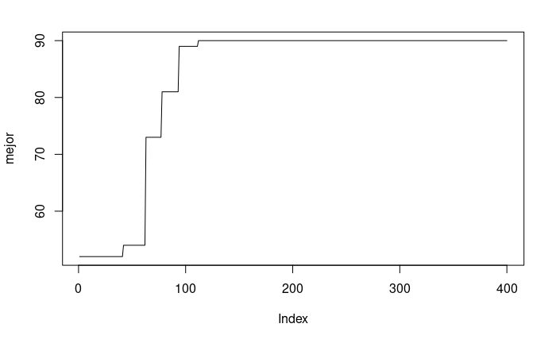

```r
# Sin gráficos intermedios para aligerar
{
#---- Colores
c_campo <- rgb(0.78, 0.95, 0.48)
c_amg <- rgb(0, 0.31, 0.74)
c_espar <- rgb(0.45, 0.55, 0.15)

#---- Espacio
xmax <- 100  # ancho de la pradera (desde x = 1 hasta x = 100)
ymax <- 100  # largo "        "    (desde y = 1 hasta y = 100)

#---- Veces
veces <- 400
mejor <- numeric(veces)

#---- Tiempo
pasos <- 1000

#---- Movimiento
Dx <- c(0, 1, 0, -1)
Dy <- c(1, 0, -1, 0)
rota <- c(0, 270, 180, 90)

#---- Estados
estados <- "AB"

#---- Autómatas
automatas <- 12

#---- Cromosomas al azar menos el primero
cromNa <- character()
cromNa[1] <- "110120121121130110" # versión numérica, más fácil de leer
for (i in 2:automatas){
  cromNa[i] <- ""
  for (j in 1:2) {
    for (k in 1:3){
      cromNa[i] <- paste(cromNa[i], sample(c(0,1), 1), sep = "") # lo que escribe
      cromNa[i] <- paste(cromNa[i], sample(c(1,2,3,4), 1), sep = "") # donde se mueve
      cromNa[i] <- paste(cromNa[i], sample(c(0,1), 1), sep = "") # nuevo estado
    }
  }
}

#---- Espárragos
Aea <- numeric(automatas)


for (vez in 1:veces){

    #---- JUGAR DE UNO EN UNO

    for (i in 1:automatas){

        #---- Pradera con esparragueras
        XYespar <- t(as.matrix(read.table("XYesp.txt")))
        # par(pty = "s", mar = c(1, 1, 1, 1), xaxt = "n", yaxt = "n",
        #     xaxs = "i", yaxs="i", ann = FALSE)
        # image(x = 1:xmax, y = 1:ymax, XYespar, xlim = c(1,xmax), ylim = c(1,ymax),
        #       col = c(c_campo, c_espar))

        #---- Posición y estado iniciales
        Ax <- ceiling(0.5*xmax)
        Ay <- ceiling(0.5*xmax)
        As <- 0  # estado A
        Ae <- 0  # sin espárragos
        # text(Ax, Ay, "A", col = "white")

        #---- Paseo
        for (t in 2:pasos){

          # Mirar qué hay en la casilla
          huella  <- XYespar[Ax, Ay]

          # Coger espárrago (si lo hubiera)
          if (huella == 2) {Ae <- Ae + 1}

          # Aplicar la regla

          posi <- 9*As + 3*huella + 1  # para la nueva huella
          n_huella <- as.numeric(substring(cromNa[i], posi, posi))
          XYespar[Ax, Ay] <- n_huella

          posi <- 9*As + 3*huella + 2  # para el movimiento
          Ad <- as.numeric(substring(cromNa[i], posi, posi))

          posi <- 9*As + 3*huella + 3  # para el estado
          n_As <- as.numeric(substring(cromNa[i], posi, posi))
          As <- n_As

          # Moverse

          Ax <- Ax + Dx[Ad]
          Ay <- Ay + Dy[Ad]
          if(Ax > xmax) {Ax <- 1} # por si se sale
          if(Ax < 1) {Ax <- xmax}
          if(Ay > ymax) {Ay <- 1}
          if(Ay < 1) {Ay <- ymax}

          # # Dibujamos la nueva posición
          # text(Ax, Ay, substring(estados, As + 1, As + 1 ),
          #      col = rgb(0, 0.31, 0.74, alpha = 0.31), srt = rota[Ad])
        }

        #---- Asignar puntos
        Aea[i] <- Ae
    }

    #---- Ver quién gana y pierde
    e_ganador <- max(Aea)
    ganador <- min(which(Aea == e_ganador)) # para que solo salga uno
    e_pringao <- min(Aea)
    pringao <- max(which(Aea == e_pringao)) # para que solo salga uno

    # print(paste("Juego:",vez))
    # print(Aea)
    # print(paste("Ganador", ganador, "con", e_ganador, "puntos."))
    # print(paste("Pringao", pringao, "con", e_pringao, "puntos."))
    mejor[vez] <- e_ganador

    #---- Tranfulla 1 (copiar del ganador)
    amigo <- ganador  # para copiar el resto del cartón
    while (amigo == ganador){
      amigo <- floor(automatas*runif(1)) + 1
    }
    cromNa[pringao] <- cromNa[amigo]
    l_cromo <- nchar(cromNa[1])
    pc <- floor(l_cromo*runif(1)) + 1
    fc <- floor(l_cromo*runif(1)) + 1
    if (pc <= fc){
      substring(cromNa[pringao], pc, fc) <- substring(cromNa[ganador], pc, fc)
    } else {
        substring(cromNa[pringao], 1, fc) <- substring(cromNa[ganador], 1, fc)
        substring(cromNa[pringao], pc, l_cromo) <- substring(cromNa[ganador], pc, l_cromo)
    }

    #---- Tranfulla 2 (copiar algún número al tuntún)
    amigo <- floor(automatas*runif(1)) + 1
    pc <- floor(l_cromo*runif(1)) + 1
    ifelse(pc%%3 == 0, # cambia el estado final
           substring(cromNa[amigo], pc, pc) <- as.character(sample(c(0,1), 1)),
           ifelse(pc%%3 == 1, # cambia la nueva huella
                  substring(cromNa[amigo], pc, pc) <- as.character(sample(c(0,1), 1)),
                  substring(cromNa[amigo], pc, pc) <- as.character(sample(c(1,2,3,4), 1)))
           )
}
plot(mejor, type = "l")
}
```

—¡Sorprendente! —No podía creer que en solo 100 juegos se pudiese mejorar tanto la estrategia del autómata que él había diseñado—. A ver qué cromosoma tiene…

`031031030111020140`, que se descodifica como la Figura 7.

[figure not shown]

[video not shown]

**Figura 8. Paseo del autómata ganador después de 100 ciclos de evolución.** De alguna manera *había aprendido* a darse la vuelta y volver a la esparraguera cuando se salía de ella. Abundio flipaba.

Ante el éxito del proceso evolutivo, Abundio decidió descartar su autómata inicial y empezar el juego con todos los cartones al azar.

¡Esta vez incluso mejor! Aunque la eficacia inicial era inferior al autómata diseñado por Abundio, enseguida aumentó y, un poco más tarde, casi se triplicó. En esta ocasión, el mejor autómata era completamente distinto al anterior (Figura 9) aunque su comportamiento era muy parecido (Figura 10).

[figure not shown]

**Figura 9. Otro autómata evolucionado.** Este era `121110111120011041` de aspecto distinto, pero comportamiento similar.

[video not shown]

**Figura 10. Paseo del nuevo autómata ganador.** Su cromosoma era completamente distinto al anterior, pero su comportamiento se parecía mucho: lo que el otro hacía de norte a sur, éste lo hace de oeste a este.

[figure not shown]

**Figura 11. Y otro más.** Este no era tan bueno como los anteriores, pero también mejoraba el diseño de Abundio.

[video not shown]

**Figura 12. Paseo de otro más.** Se dejaba la mitad de la esparraguera, pero no lo hacía mal del todo.

# Diversidad y eficacia

Con su prodigiosa capacidad para el cálculo mental, Abundio hizo más simulaciones y en todas salía un ganador con un cromosoma distinto. Nunca se respetía el mismo y, sin embargo, el comportamiento sobre el terreno era muy parecido.

—Parece que hay muchas formas de codificar el mismo comportamiento —concluyó.

También se dio cuenta de que la variedad de cromosomas se empobrecía mucho conforme pasaban los juegos. Por ejemplo, la última simulación acabó con este acervo genético:

032131120130140013113031013041012133, 032131120130140013113031013041012133, 032131120130140013113031013041012133, 032131120130140013113031013041012133, 032131120130140013113031013041012133, 032131120130140013113031013041012133, 032131120130140013113031013041012133, 032131120130140013113031013041012133, 032131120130140013113011013041112133, 032131120130140013113032013041012133, 032131120130140013113032013041012133, 032131120130140013113032013041012133

Todos muy parecidos. Incluso las diferencias entre el mejor y el peor en el último juego eran exiguas.

Para estar seguro, revisó sus cálculos.

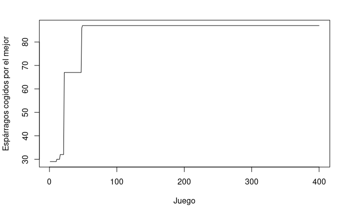

```r
# Sin gráficos intermedios para aligerar
{

#---- Espacio
xmax <- 100  # ancho de la pradera (desde x = 1 hasta x = 100)
ymax <- 100  # largo "        "    (desde y = 1 hasta y = 100)

#---- Veces
veces <- 400
mejor <- numeric(veces)

#---- Tiempo
pasos <- 1000

#---- Movimiento
Dx <- c(0, 1, 0, -1)
Dy <- c(1, 0, -1, 0)
rota <- c(0, 270, 180, 90)

#---- Estados
estados <- "AB"

#---- Autómatas
automatas <- 12

#---- Cromosomas al azar
cromNa <- character()
for (i in 1:automatas){
  cromNa[i] <- ""
  for (j in 1:2) {
    for (k in 1:3){
      cromNa[i] <- paste(cromNa[i], sample(c(0,1), 1), sep = "") # lo que escribe
      cromNa[i] <- paste(cromNa[i], sample(c(1,2,3,4), 1), sep = "") # donde se mueve
      cromNa[i] <- paste(cromNa[i], sample(c(0,1), 1), sep = "") # nuevo estado
    }
  }
}

#---- Espárragos
Aea <- numeric(automatas)


for (vez in 1:veces){

    #---- JUGAR DE UNO EN UNO

    for (i in 1:automatas){

        #---- Pradera con esparragueras
        XYespar <- t(as.matrix(read.table("XYesp.txt")))

        #---- Posición y estado iniciales
        Ax <- ceiling(0.5*xmax)
        Ay <- ceiling(0.5*xmax)
        As <- 0  # estado A
        Ae <- 0  # sin espárragos

        #---- Paseo
        for (t in 2:pasos){

          # Mirar qué hay en la casilla
          huella  <- XYespar[Ax, Ay]

          # Coger espárrago (si lo hubiera)
          if (huella == 2) {Ae <- Ae + 1}

          # Aplicar la regla

          posi <- 9*As + 3*huella + 1  # para la nueva huella
          n_huella <- as.numeric(substring(cromNa[i], posi, posi))
          XYespar[Ax, Ay] <- n_huella

          posi <- 9*As + 3*huella + 2  # para el movimiento
          Ad <- as.numeric(substring(cromNa[i], posi, posi))

          posi <- 9*As + 3*huella + 3  # para el estado
          n_As <- as.numeric(substring(cromNa[i], posi, posi))
          As <- n_As

          # Moverse

          Ax <- Ax + Dx[Ad]
          Ay <- Ay + Dy[Ad]
          if(Ax > xmax) {Ax <- 1} # por si se sale
          if(Ax < 1) {Ax <- xmax}
          if(Ay > ymax) {Ay <- 1}
          if(Ay < 1) {Ay <- ymax}

        }

        #---- Asignar puntos
        Aea[i] <- Ae
    }

    #---- Ver quién gana y pierde
    e_ganador <- max(Aea)
    ganador <- min(which(Aea == e_ganador)) # para que solo salga uno
    e_pringao <- min(Aea)
    pringao <- min(which(Aea == e_pringao)) # para que solo salga uno
    mejor[vez] <- e_ganador

    #---- Tranfulla 1 (copiar del ganador)
    amigo <- ganador  # para copiar el resto del cartón
    while (amigo == ganador){
      amigo <- floor(automatas*runif(1)) + 1
    }
    l_cromo <- nchar(cromNa[1])
    pc <- floor(l_cromo*runif(1)) + 1
    fc <- floor(l_cromo*runif(1)) + 1

    if (pc < fc) {
      cromNa[pringao] <- cromNa[amigo]
      substring(cromNa[pringao], pc, fc-1) <- substring(cromNa[ganador], pc, fc-1)
    }

    if (fc < pc) {
      cromNa[pringao] <- cromNa[ganador]
      substring(cromNa[pringao], fc, pc-1) <- substring(cromNa[amigo], fc, pc-1)
    }


    #---- Tranfulla 2 (cambiar algún número al tuntún)
    amigo <- floor(automatas*runif(1)) + 1
    pc <- floor(l_cromo*runif(1)) + 1
    pcc <- substring(cromNa[amigo], pc, pc)
    ifelse(pc%%3 == 0, # cambia el estado final
           substring(cromNa[amigo], pc, pc) <- as.character((as.numeric(pcc)+1)%%2),
           ifelse(pc%%3 == 1, # cambia la nueva huella
                  substring(cromNa[amigo], pc, pc) <- as.character((as.numeric(pcc)+1)%%2),
                  substring(cromNa[amigo], pc, pc) <- as.character((as.numeric(pcc)+1)%%4 + 1)
           ))
}
plot(mejor, type = "l", ylab = "Espárragos cogidos por el mejor", xlab = "Juego")
}
```

**Figura 13. Resultado del nuevo código.** Parece que funciona un poco más fino, pero es solo intuición.

032131120130140013113031013041012133, 032131120130140013113031013041012133, 032131120130140013113031013041012133, 032131120130140013113031013041012133, 032131120130140013113031013041012133, 032131120130140013113031013041012133, 032131120130140013113031013041012133, 032131120130140013113031013041012133, 032131120130140013113011013041112133, 032131120130140013113032013041012133, 032131120130140013113032013041012133, 032131120130140013113032013041012133

Había 3 cromosomas distintos al final de los cuatrocientos juegos, aunque la eficacia no parecía mucho mayor.

# ¿Otro tipo de movimiento?

De repente, recordó que en el juego inicial se usaba otra regla para el movimiento. Antes se giraba en una dirección cuando ocurría algo. ¿Tendrá esto alguna importancia?

[figure not shown]

**Figura 14. Direcciones relativas.** Si Abundio miraba al norte y le salía un 2, se giraba a la derecha. Y con él todos los movimientos relativos.

—Pero… —se quedó dubitativo— ¡entonces la dirección en la que anda es como si fuese un estado!

¡Claro! Para mejorar la capacidad evolutiva, tendría que añadir nuevos estados!

# Con tres estados

Añadió un nuevo estado: `U` y se puso a jugar.

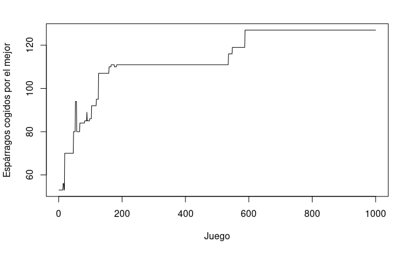

```r
# 3 estados
{

#---- Espacio
xmax <- 100  # ancho de la pradera (desde x = 1 hasta x = 100)
ymax <- 100  # largo "        "    (desde y = 1 hasta y = 100)

#---- Veces
veces <- 1000
mejor <- numeric(veces)

#---- Tiempo
pasos <- 1000

#---- Movimiento
Dx <- c(0, 1, 0, -1)
Dy <- c(1, 0, -1, 0)
rota <- c(0, 270, 180, 90)

#---- Estados
estados <- "ABU"

#---- Autómatas
automatas <- 12

#---- Cromosomas al azar
cromNa <- character()
for (i in 1:automatas){
  cromNa[i] <- ""
  for (j in 1:3) {
    for (k in 1:3){
      cromNa[i] <- paste(cromNa[i], sample(c(0,1), 1), sep = "") # lo que escribe
      cromNa[i] <- paste(cromNa[i], sample(c(1,2,3,4), 1), sep = "") # donde se mueve
      cromNa[i] <- paste(cromNa[i], sample(c(0,1,2), 1), sep = "") # nuevo estado
    }
  }
}

#---- Espárragos
Aea <- numeric(automatas)


for (vez in 1:veces){

    #---- JUGAR DE UNO EN UNO

    for (i in 1:automatas){

        #---- Pradera con esparragueras
        XYespar <- t(as.matrix(read.table("XYesp.txt")))

        #---- Posición y estado iniciales
        Ax <- ceiling(0.5*xmax)
        Ay <- ceiling(0.5*xmax)
        As <- 0  # estado A
        Ae <- 0  # sin espárragos

        #---- Paseo
        for (t in 2:pasos){

          # Mirar qué hay en la casilla
          huella  <- XYespar[Ax, Ay]

          # Coger espárrago (si lo hubiera)
          if (huella == 2) {Ae <- Ae + 1}

          # Aplicar la regla

          posi <- 9*As + 3*huella + 1  # para la nueva huella
          n_huella <- as.numeric(substring(cromNa[i], posi, posi))
          XYespar[Ax, Ay] <- n_huella

          posi <- 9*As + 3*huella + 2  # para el movimiento
          Ad <- as.numeric(substring(cromNa[i], posi, posi))

          posi <- 9*As + 3*huella + 3  # para el estado
          n_As <- as.numeric(substring(cromNa[i], posi, posi))
          As <- n_As

          # Moverse

          Ax <- Ax + Dx[Ad]
          Ay <- Ay + Dy[Ad]
          if(Ax > xmax) {Ax <- 1} # por si se sale
          if(Ax < 1) {Ax <- xmax}
          if(Ay > ymax) {Ay <- 1}
          if(Ay < 1) {Ay <- ymax}

        }

        #---- Asignar puntos
        Aea[i] <- Ae
    }

    #---- Ver quién gana y pierde
    e_ganador <- max(Aea)
    ganador <- min(which(Aea == e_ganador)) # para que solo salga uno
    e_pringao <- min(Aea)
    pringao <- min(which(Aea == e_pringao)) # para que solo salga uno
    mejor[vez] <- e_ganador

    #---- Tranfulla 1 (copiar del ganador)
    amigo <- ganador  # para copiar el resto del cartón
    while (amigo == ganador){
      amigo <- floor(automatas*runif(1)) + 1
    }
    l_cromo <- nchar(cromNa[1])
    pc <- floor(l_cromo*runif(1)) + 1
    fc <- floor(l_cromo*runif(1)) + 1

    if (pc < fc) {
      cromNa[pringao] <- cromNa[amigo]
      substring(cromNa[pringao], pc, fc-1) <- substring(cromNa[ganador], pc, fc-1)
    }

    if (fc < pc) {
      cromNa[pringao] <- cromNa[ganador]
      substring(cromNa[pringao], fc, pc-1) <- substring(cromNa[amigo], fc, pc-1)
    }


    #---- Tranfulla 2 (cambiar algún número al tuntún)
    amigo <- floor(automatas*runif(1)) + 1
    pc <- floor(l_cromo*runif(1)) + 1
    pcc <- substring(cromNa[amigo], pc, pc)
    ifelse(pc%%3 == 0, # cambia el estado final
           substring(cromNa[amigo], pc, pc) <- as.character((as.numeric(pcc)+1)%%3),
           ifelse(pc%%3 == 1, # cambia la nueva huella
                  substring(cromNa[amigo], pc, pc) <- as.character((as.numeric(pcc)+1)%%2),
                  substring(cromNa[amigo], pc, pc) <- as.character((as.numeric(pcc)+1)%%4 + 1)
           ))
}
plot(mejor, type = "l", ylab = "Espárragos cogidos por el mejor", xlab = "Juego")
}
```

[video not shown]

**Figura 16. Paseo con 3 estados.** Se dejaba la mitad de la esparraguera, pero no lo hacía mal del todo, un poco mejor.

# Esparragueras cambiantes

¿Qué pasaría si las esparragueras se cambiasen de lugar cada vez?

```r
# 3 estados
{

#---- Espacio y esparragueras
xmax <- 100  # ancho de la pradera (desde x = 1 hasta x = 100)
ymax <- 100  # largo "        "    (desde y = 1 hasta y = 100)
esp <- 9
xe <- runif(esp)
ye <- runif(esp)
re <- round(runif(esp, min = 1, max = 6))

#---- Veces
veces <- 1000
mejor <- numeric(veces)

#---- Tiempo
pasos <- 1000

#---- Movimiento
Dx <- c(0, 1, 0, -1)
Dy <- c(1, 0, -1, 0)
rota <- c(0, 270, 180, 90)

#---- Estados
estados <- "ABU"

#---- Autómatas
automatas <- 12

#---- Cromosomas al azar
cromNa <- character()
for (i in 1:automatas){
  cromNa[i] <- ""
  for (j in 1:3) {
    for (k in 1:3){
      cromNa[i] <- paste(cromNa[i], sample(c(0,1), 1), sep = "") # lo que escribe
      cromNa[i] <- paste(cromNa[i], sample(c(1,2,3,4), 1), sep = "") # donde se mueve
      cromNa[i] <- paste(cromNa[i], sample(c(0,1,2), 1), sep = "") # nuevo estado
    }
  }
}

#---- Espárragos
Aea <- numeric(automatas)


for (vez in 1:veces){

    #---- JUGAR DE UNO EN UNO

    for (i in 1:automatas){

        #---- Pradera con esparragueras
        # XYespar <- t(as.matrix(read.table("XYesp.txt")))
        #---- Posición de las esparragueras
        XYespar <- matrix(0, xmax, ymax)
        # pixelar la Figura 2
        for (k in 1:esp){
          x <- ceiling(xmax*xe[k])
          y <- ceiling(ymax*ye[k])
          # ¿Cómo pixelar un círculo con teselas de lado = 1?
          for (yi in 0:re[k]){
            y_arr <- y + yi
            if(y_arr > ymax) {y_arr <- y_arr - ymax} # por si se sale
            y_abj <- y - yi
            if(y_abj < 1) {y_abj <- ymax + y_abj}
            borde <- sqrt(re[k]^2 - yi^2)
            for (xi in 0:borde){
              x_der <- x + xi
              if(x_der > xmax) {x_der <- x_der - xmax}
              x_izq <- x - xi
              if(x_izq < 1) {x_izq <- xmax + x_izq}
              # points(x_der, y_arr, pch = 15, col = c_espar, cex = 0.6)
              XYespar[x_der, y_arr] <- 2
              # points(x_izq, y_arr, pch = 15, col = c_espar, cex = 0.6)
              XYespar[x_izq, y_arr] <- 2
              # points(x_der, y_abj, pch = 15, col = c_espar, cex = 0.6)
              XYespar[x_der, y_abj] <- 2
              # points(x_izq, y_abj, pch = 15, col = c_espar, cex = 0.6)
              XYespar[x_izq, y_abj] <- 2
            }
          }
        }

        #---- Posición y estado iniciales
        Ax <- ceiling(0.5*xmax)
        Ay <- ceiling(0.5*xmax)
        As <- 0  # estado A
        Ae <- 0  # sin espárragos

        #---- Paseo
        for (t in 2:pasos){

          # Mirar qué hay en la casilla
          huella  <- XYespar[Ax, Ay]

          # Coger espárrago (si lo hubiera)
          if (huella == 2) {Ae <- Ae + 1}

          # Aplicar la regla

          posi <- 9*As + 3*huella + 1  # para la nueva huella
          n_huella <- as.numeric(substring(cromNa[i], posi, posi))
          XYespar[Ax, Ay] <- n_huella

          posi <- 9*As + 3*huella + 2  # para el movimiento
          Ad <- as.numeric(substring(cromNa[i], posi, posi))

          posi <- 9*As + 3*huella + 3  # para el estado
          n_As <- as.numeric(substring(cromNa[i], posi, posi))
          As <- n_As

          # Moverse

          Ax <- Ax + Dx[Ad]
          Ay <- Ay + Dy[Ad]
          if(Ax > xmax) {Ax <- 1} # por si se sale
          if(Ax < 1) {Ax <- xmax}
          if(Ay > ymax) {Ay <- 1}
          if(Ay < 1) {Ay <- ymax}

        }

        #---- Asignar puntos
        Aea[i] <- Ae
    }

    #---- Ver quién gana y pierde
    e_ganador <- max(Aea)
    ganador <- min(which(Aea == e_ganador)) # para que solo salga uno
    e_pringao <- min(Aea)
    pringao <- min(which(Aea == e_pringao)) # para que solo salga uno
    mejor[vez] <- e_ganador

    #---- Tranfulla 1 (copiar del ganador)
    amigo <- ganador  # para copiar el resto del cartón
    while (amigo == ganador){
      amigo <- floor(automatas*runif(1)) + 1
    }
    l_cromo <- nchar(cromNa[1])
    pc <- floor(l_cromo*runif(1)) + 1
    fc <- floor(l_cromo*runif(1)) + 1

    if (pc < fc) {
      cromNa[pringao] <- cromNa[amigo]
      substring(cromNa[pringao], pc, fc-1) <- substring(cromNa[ganador], pc, fc-1)
    }

    if (fc < pc) {
      cromNa[pringao] <- cromNa[ganador]
      substring(cromNa[pringao], fc, pc-1) <- substring(cromNa[amigo], fc, pc-1)
    }


    #---- Tranfulla 2 (cambiar algún número al tuntún)
    amigo <- floor(automatas*runif(1)) + 1
    pc <- floor(l_cromo*runif(1)) + 1
    pcc <- substring(cromNa[amigo], pc, pc)
    ifelse(pc%%3 == 0, # cambia el estado final
           substring(cromNa[amigo], pc, pc) <- as.character((as.numeric(pcc)+1)%%3),
           ifelse(pc%%3 == 1, # cambia la nueva huella
                  substring(cromNa[amigo], pc, pc) <- as.character((as.numeric(pcc)+1)%%2),
                  substring(cromNa[amigo], pc, pc) <- as.character((as.numeric(pcc)+1)%%4 + 1)
           ))
}
plot(mejor, type = "l", ylab = "Espárragos cogidos por el mejor", xlab = "Juego")
}
```

[output not shown]

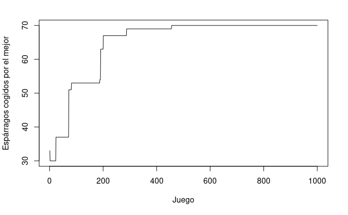

```r
# 3 estados
{

#---- Espacio y esparragueras
xmax <- 100  # ancho de la pradera (desde x = 1 hasta x = 100)
ymax <- 100  # largo "        "    (desde y = 1 hasta y = 100)
esp <- 9
xe <- runif(esp)
ye <- runif(esp)
re <- round(runif(esp, min = 1, max = 6))

#---- Veces
veces <- 1000
mejor <- numeric(veces)

#---- Tiempo
pasos <- 400

#---- Movimiento
Dx <- c(0, 1, 0, -1)
Dy <- c(1, 0, -1, 0)
rota <- c(0, 270, 180, 90)

#---- Estados
estados <- "ABUN"

#---- Autómatas
automatas <- 12

#---- Cromosomas al azar
cromNa <- character()
for (i in 1:automatas){
  cromNa[i] <- ""
  for (j in 1:nchar(estados)) {
    for (k in 1:3){
      cromNa[i] <- paste(cromNa[i], sample(c(0,1), 1), sep = "") # lo que escribe
      cromNa[i] <- paste(cromNa[i], sample(c(1,2,3,4), 1), sep = "") # donde se mueve
      cromNa[i] <- paste(cromNa[i], sample(c(0,1,2,3), 1), sep = "") # nuevo estado
    }
  }
}

#---- Espárragos
Aea <- numeric(automatas)


for (vez in 1:veces){

    #---- JUGAR DE UNO EN UNO

    for (i in 1:automatas){

        #---- Pradera con esparragueras
        # XYespar <- t(as.matrix(read.table("XYesp.txt")))
        #---- Posición de las esparragueras
        XYespar <- matrix(0, xmax, ymax)
        # pixelar la Figura 2
        for (k in 1:esp){
          x <- ceiling(xmax*xe[k])
          y <- ceiling(ymax*ye[k])
          # ¿Cómo pixelar un círculo con teselas de lado = 1?
          for (yi in 0:re[k]){
            y_arr <- y + yi
            if(y_arr > ymax) {y_arr <- y_arr - ymax} # por si se sale
            y_abj <- y - yi
            if(y_abj < 1) {y_abj <- ymax + y_abj}
            borde <- sqrt(re[k]^2 - yi^2)
            for (xi in 0:borde){
              x_der <- x + xi
              if(x_der > xmax) {x_der <- x_der - xmax}
              x_izq <- x - xi
              if(x_izq < 1) {x_izq <- xmax + x_izq}
              # points(x_der, y_arr, pch = 15, col = c_espar, cex = 0.6)
              XYespar[x_der, y_arr] <- 2
              # points(x_izq, y_arr, pch = 15, col = c_espar, cex = 0.6)
              XYespar[x_izq, y_arr] <- 2
              # points(x_der, y_abj, pch = 15, col = c_espar, cex = 0.6)
              XYespar[x_der, y_abj] <- 2
              # points(x_izq, y_abj, pch = 15, col = c_espar, cex = 0.6)
              XYespar[x_izq, y_abj] <- 2
            }
          }
        }

        #---- Posición y estado iniciales
        Ax <- ceiling(0.5*xmax)
        Ay <- ceiling(0.5*xmax)
        As <- 0  # estado A
        Ae <- 0  # sin espárragos

        #---- Paseo
        for (t in 2:pasos){

          # Mirar qué hay en la casilla
          huella  <- XYespar[Ax, Ay]

          # Coger espárrago (si lo hubiera)
          if (huella == 2) {Ae <- Ae + 1}

          # Aplicar la regla

          posi <- 9*As + 3*huella + 1  # para la nueva huella
          n_huella <- as.numeric(substring(cromNa[i], posi, posi))
          XYespar[Ax, Ay] <- n_huella

          posi <- 9*As + 3*huella + 2  # para el movimiento
          Ad <- as.numeric(substring(cromNa[i], posi, posi))

          posi <- 9*As + 3*huella + 3  # para el estado
          n_As <- as.numeric(substring(cromNa[i], posi, posi))
          As <- n_As

          # Moverse

          Ax <- Ax + Dx[Ad]
          Ay <- Ay + Dy[Ad]
          if(Ax > xmax) {Ax <- 1} # por si se sale
          if(Ax < 1) {Ax <- xmax}
          if(Ay > ymax) {Ay <- 1}
          if(Ay < 1) {Ay <- ymax}

        }

        #---- Asignar puntos
        Aea[i] <- Ae
    }

    #---- Ver quién gana y pierde
    e_ganador <- max(Aea)
    ganador <- min(which(Aea == e_ganador)) # para que solo salga uno
    e_pringao <- min(Aea)
    pringao <- min(which(Aea == e_pringao)) # para que solo salga uno
    mejor[vez] <- e_ganador

    #---- Tranfulla 1 (copiar del ganador)
    amigo <- ganador  # para copiar el resto del cartón
    while (amigo == ganador){
      amigo <- floor(automatas*runif(1)) + 1
    }
    l_cromo <- nchar(cromNa[1])
    pc <- floor(l_cromo*runif(1)) + 1
    fc <- floor(l_cromo*runif(1)) + 1

    if (pc < fc) {
      cromNa[pringao] <- cromNa[amigo]
      substring(cromNa[pringao], pc, fc-1) <- substring(cromNa[ganador], pc, fc-1)
    }

    if (fc < pc) {
      cromNa[pringao] <- cromNa[ganador]
      substring(cromNa[pringao], fc, pc-1) <- substring(cromNa[amigo], fc, pc-1)
    }


    #---- Tranfulla 2 (cambiar algún número al tuntún)
    amigo <- floor(automatas*runif(1)) + 1
    pc <- floor(l_cromo*runif(1)) + 1
    pcc <- substring(cromNa[amigo], pc, pc)
    ifelse(pc%%3 == 0, # cambia el estado final
           substring(cromNa[amigo], pc, pc) <- as.character((as.numeric(pcc)+1)%%4),
           ifelse(pc%%3 == 1, # cambia la nueva huella
                  substring(cromNa[amigo], pc, pc) <- as.character((as.numeric(pcc)+1)%%2),
                  substring(cromNa[amigo], pc, pc) <- as.character((as.numeric(pcc)+1)%%4 + 1)
           ))
}
plot(mejor, type = "l", ylab = "Espárragos cogidos por el mejor", xlab = "Juego")
}
```

[video not shown]

**Figura 17. Paseo con 4 estados.** Se dejaba la mitad de la esparraguera, pero no lo hacía mal del todo, un poco mejor.